# TP Biodiversité-Concentration n°4

2023-06-19

# Données de Paracou

## Lecture

Les données sont disponibles dans le package *dbmss*.

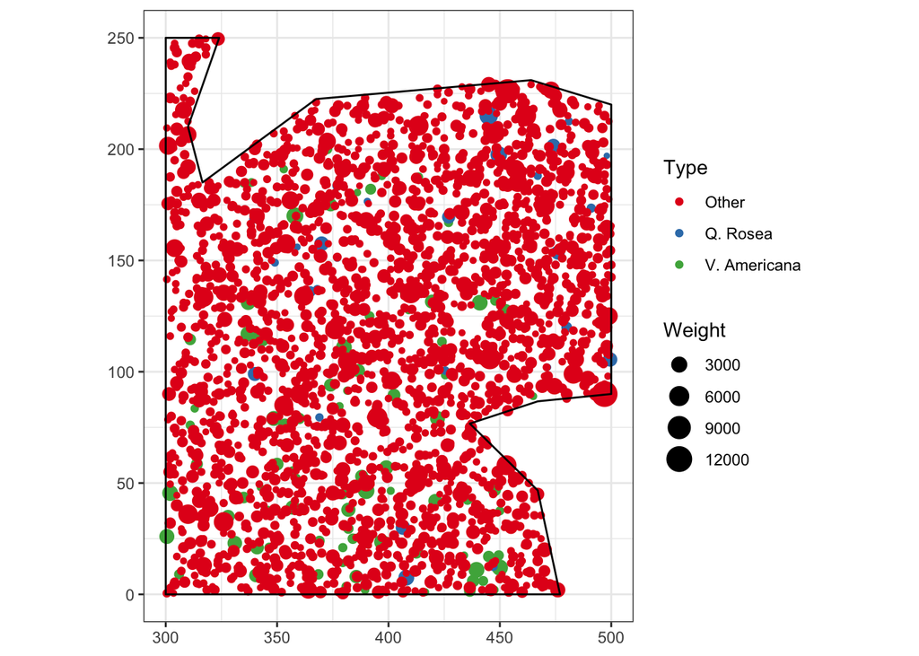

```r
library("dbmss")
data(paracou16)
# Plot (second column of marks is Point Types)
autoplot(paracou16, which.marks=2, leg.side="right")
```

# Concentation spatiale relative

## M intratype

Les wacapous (*Vouacapoua americana*) sont-ils concentrés relativement à la distribution globale des arbres ?

```r
NumberOfSimulations <- 100#0 pour réduire le temps de calcul
r <- 0:30
(Va_Menv <- MEnvelope(
  paracou16,
  r = r,
  NumberOfSimulations = NumberOfSimulations,
  ReferenceType = "V. Americana"
))
```

```
## Local critical envelopes obtained from 100 simulations of M(r) under the null hypothesis: Random Location
## (All 100 simulated function values are stored in attr(, "simfuns" ) )
## Significance level of Monte Carlo test: 0.05
## Data: X
## ..................................................
##       Math.label
## r     r
## obs   hat(M)[obs](r)
## mmean bar(M)(r)
## lo    hat(M)[lo](r)
## hi    hat(M)[hi](r)
##       Description
## r     distance argument r
## obs   observed value of M(r) for data pattern
## mmean sample mean of M(r) from simulations
## lo    lower pointwise envelope of M(r) from [..]
## hi    upper pointwise envelope of M(r) from [..]
## ..................................................
## Default plot formula:  .~r
## where "." stands for 'obs', 'mmean', 'hi', 'lo'
## Columns 'lo' and 'hi' will be plotted as shading
## (by default)
## Recommended range of argument r: [0, 30]
## Available range of argument r: [0, 30]
## Unit of length: 1 meter
```

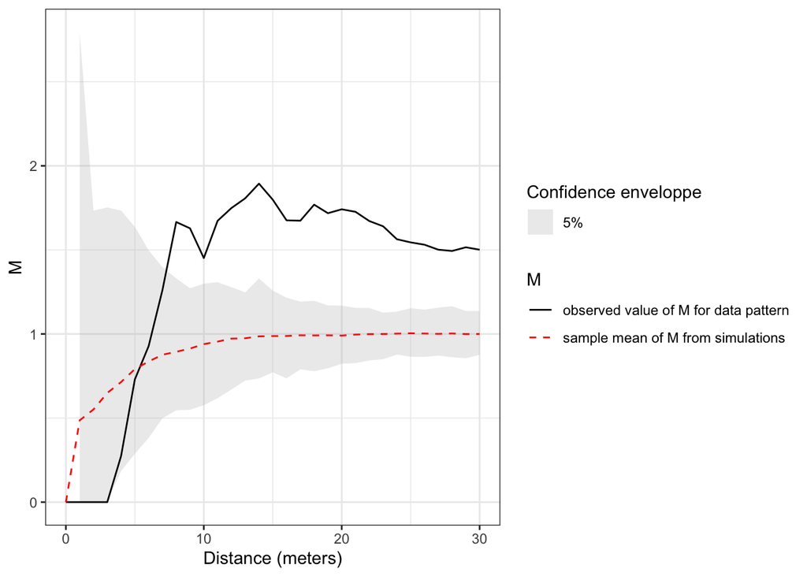

```r
# Plot
autoplot(Va_Menv)
```

L’hypothèse nulle est la “localisation aléatoire” : les points sont redistribués sur les emplacements occupés par les points réels.

L’attraction entre les arbres est significative.

## M intertype

Les gonfolos (*Qualea Rosea*) sont-ils concentrés autour des wacapous (*Vouacapoua americana*) relativement à la distribution globale des arbres ?

```r
NumberOfSimulations <- 100#0 pour réduire le temps de calcul
(VaQr_Menv <- MEnvelope(
  paracou16,
  r = r,
  NumberOfSimulations = NumberOfSimulations,
  ReferenceType = "V. Americana",
  NeighborType = "Q. Rosea"
))
```

```
## Local critical envelopes obtained from 100 simulations of M(r) under the null hypothesis: Random Location
## (All 100 simulated function values are stored in attr(, "simfuns" ) )
## Significance level of Monte Carlo test: 0.05
## Data: X
## ..................................................
##       Math.label
## r     r
## obs   hat(M)[obs](r)
## mmean bar(M)(r)
## lo    hat(M)[lo](r)
## hi    hat(M)[hi](r)
##       Description
## r     distance argument r
## obs   observed value of M(r) for data pattern
## mmean sample mean of M(r) from simulations
## lo    lower pointwise envelope of M(r) from [..]
## hi    upper pointwise envelope of M(r) from [..]
## ..................................................
## Default plot formula:  .~r
## where "." stands for 'obs', 'mmean', 'hi', 'lo'
## Columns 'lo' and 'hi' will be plotted as shading
## (by default)
## Recommended range of argument r: [0, 30]
## Available range of argument r: [0, 30]
## Unit of length: 1 meter
```

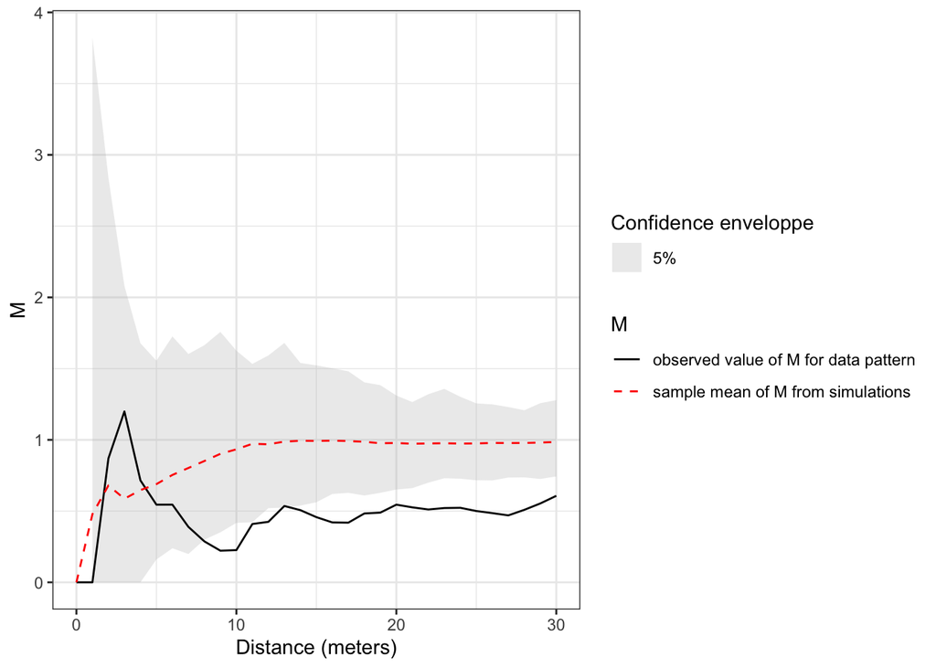

```r
# Plot
autoplot(VaQr_Menv)
```

Les wacapous et les gonfolos se repoussent. Vérifier que la répulsion est significative dans les deux sens.

# m

Les wacapous (*Vouacapoua americana*) sont concentrés relativement à la distribution globale des arbres. A quelle distance l’attraction se produit-elle ?

```r
NumberOfSimulations <- 10#00 pour réduire le temps de calcul
(Va_menv <- mEnvelope(
  paracou16,
  r = r,
  NumberOfSimulations = NumberOfSimulations,
  ReferenceType = "V. Americana"
))
```

```
## Local critical envelopes obtained from 10 simulations of m(r) under the null hypothesis: Random Location
## (All 10 simulated function values are stored in attr(, "simfuns" ) )
## Significance level of Monte Carlo test: 0.05
## Data: X
## ..................................................
##       Math.label
## r     r
## obs   hat(m)[obs](r)
## mmean bar(m)(r)
## lo    hat(m)[lo](r)
## hi    hat(m)[hi](r)
##       Description
## r     distance argument r
## obs   observed value of m(r) for data pattern
## mmean sample mean of m(r) from simulations
## lo    lower pointwise envelope of m(r) from [..]
## hi    upper pointwise envelope of m(r) from [..]
## ..................................................
## Default plot formula:  .~r
## where "." stands for 'obs', 'mmean', 'hi', 'lo'
## Columns 'lo' and 'hi' will be plotted as shading
## (by default)
## Recommended range of argument r: [0, 30]
## Available range of argument r: [0, 30]
## Unit of length: 1 meter
```

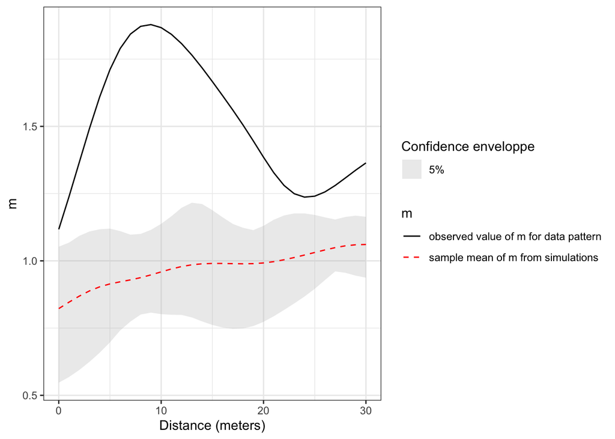

```r
# Plot
autoplot(Va_menv)
```

A un peu moins de 10 m de distance, l’attraction est maximale : on y trouve presque deux fois plus de voisins que sous l’hypothèse nulle.

# Kd

La fonction $K_d$ de Duranton et Overman est une fonction de densité, absolue : elle mesure les interactions à distance (et non jusqu’à une distance) sans référence (ni à l’espace, ni à la densité de l’ensemble des points). Sa valeur est la densité de probabilité de trouver un voisin à la distance $r$, sans correction des effets de bord. Elle n’a de sens que comparée à l’intervalle de confiance de son hypothèse nulle.

```r
NumberOfSimulations <- 10#00 pour réduire le temps de calcul
(Va_Kdenv <- KdEnvelope(
  paracou16,
  r = r,
  NumberOfSimulations = NumberOfSimulations,
  ReferenceType = "V. Americana"
))
```

```
## Local critical envelopes obtained from 10 simulations of Kd(r) under the null hypothesis: Random Location
## (All 10 simulated function values are stored in attr(, "simfuns" ) )
## Significance level of Monte Carlo test: 0.05
## Data: X
## ..................................................
##       Math.label
## r     r
## obs   hat(Kd)[obs](r)
## mmean bar(Kd)(r)
## lo    hat(Kd)[lo](r)
## hi    hat(Kd)[hi](r)
##       Description
## r     distance argument r
## obs   observed value of Kd(r) for data pattern
## mmean sample mean of Kd(r) from simulations
## lo    lower pointwise envelope of Kd(r) from [..]
## hi    upper pointwise envelope of Kd(r) from [..]
## ..................................................
## Default plot formula:  .~r
## where "." stands for 'obs', 'mmean', 'hi', 'lo'
## Columns 'lo' and 'hi' will be plotted as shading
## (by default)
## Recommended range of argument r: [0, 30]
## Available range of argument r: [0, 30]
## Unit of length: 1 meter
```

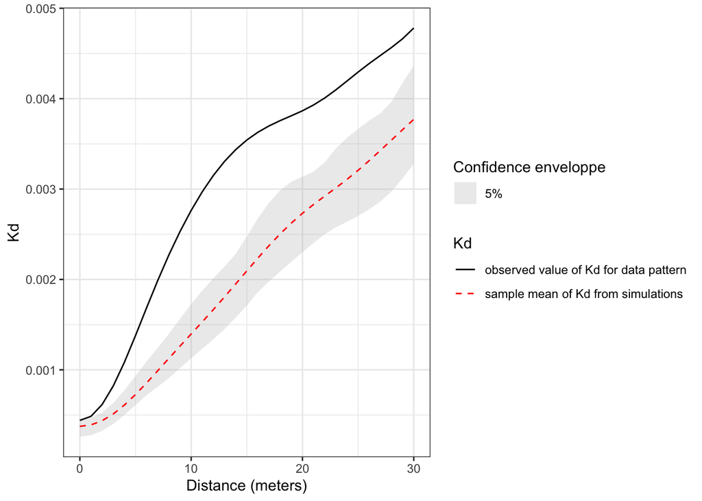

```r
# Plot
autoplot(Va_Kdenv)
```